# SOPHiA assignment

Lukas Leiendecker

2023-01-19

# Task

The complete task should contain the following files

1. readme.txt
2. AH_S1_L001_R1.fastq.gz
3. AH_S1_L001_R2.fastq.gz
4. AH_S1_target.txt
5. CH_S2_L001_R1.fastq.gz
6. CH_S2_L001_R2.fastq.gz
7. CH_S2_target.txt

The two datasets (S1 and S2) of paired-end short reads are from the SAME human DNA NGS library for clinical diagnosis of solid tumor. They were obtained through two different target sequencing approaches with corresponding target region file provided (hg19).

Please evaluate their performances as much as you can and compile your results into a task report to submit back.

1. the task has to be finished in one week by yourself
2. if the two approaches are wrapped into two commercial NGS products, which one would you chose in your lab for clinical diagnose? And why?

# Raw read QC

### Read Distribution

First, let’s have a look at the general QC of the paired-end FASTQ.GZ files by utilizing [fastQC](https://www.bioinformatics.babrS1am.ac.uk/projects/fastqc/) and fastp to generate sample performance metrics.

Below a plot of the unique/duplicate reads in both approaches. Generally speaking, a good library and sequencing run should have a low amount of duplicate reads.

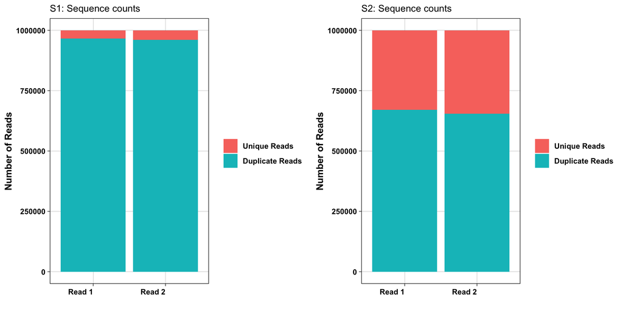

Both datasets contain a total of ~2M paired-end reads (forward and reverse reads each ~1M). The extremely high duplication rate in the S1 approach (>90%) warrants further investigation and suggests an over-amplification of the library together with a low complexity enrichment of target sequences during the library capturing approach. The S2 approach shows a read duplication rate of ~65%, which is high for a WGS library, but might be appropriate for a targeted sequence enrichment approach as it is the case here.

### Sequence duplication levels

To further investigate the high read duplication rate, I investigated the relative level of duplication for every sequence.

Generally, a low level of sequence duplication indicates a high level of target sequence coverage, and a high level of duplication is likely to indicate an enrichment bias (e.g., PCR over-amplification). Accordingly, in a diverse library the majority of sequences should fall into the left site of the plot with a predominantly low sequence duplication level.

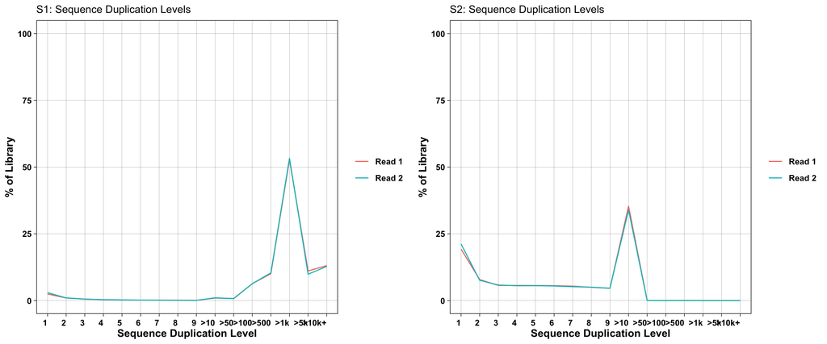

In the S1 approach, more than 50% of the library are duplicated >1k, indicating a significant enrichment of low complexity sequences. For the S2 approach, the sequence duplication levels are overall better, with a generally stronger enrichment towards lower sequence duplication levels and only ~35% of the library being duplicated >10. A reason for such a strong sequence duplication level in the S1 approach could be the inefficient target sequence capture and subsequent over-amplification, or free-adapters or mono-nucleotide reads resulting in a low complexity sample.

Comparing the over-represented sequences in the S1 sample to a database of common contaminants using FastQC, I find that the highly abundant reads are not known common contaminates, but rather are the consequence of a strong over-amplification of the library as the consequence of poor target-sequence enrichment. The top 5 most-abundant sequences are listed below:

| Sequence | Abundance [%] | Locus |
| --- | --- | --- |
| AGAGCATACGCAGCCTGTACCCAGTGGTGCCGAGCCTCTGGCGGTGCCAA | 1.9278 | RET gene locus |
| CTCCAGGAAGCCTACGTGATGGCCAGCGTGGACAACCCCCACGTGTGCCG | 1.909 | EGFR gene locus |
| GACCGCATGTGAGGATCCTGGCTCCTTATCTCCCCTCCCCGTATCTCCCT | 1.8354 | EGFR gene locus |
| CACCGGAAGAGGAGTAGCTGACCGGGAAGGCCTGGGCGGGCCTCCGGAAG | 1.552 | RET gene locus |
| GTCATCCAAATACTCCACACGCAAATTTCCTTCCACTCGGATAAGATGCT | 1.5299 | TP53 gene locus |

### Sequence quality

Next, I looked at the overall sequence quality. Here I display the mean quality value across each base position in the read. The Phread Quality Score indicates the probability of an incorrect based call at a given position. For example, a Phread Score of 30, corresponds to the probability of an incorrect base call of 1 in 1000, resulting in a base call accuracy of 99.9%.

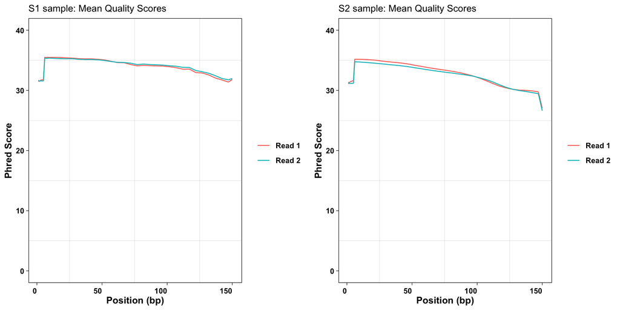

Both libraries show very good sequencing quality with the majority of the read having a Phread Score > 30. There is a slight dip in Phred Score for the last three bases in the S2 approach, however given the otherwise excellent sequence quality, both approaches perform equally well. It is frequently found that the first ~5 bases have lower quality than the rest of the read as this is due to the calibration of the sequencer, so this “abnormality” is not of concern in both approaches.

### Per Sequence GC Content

Here, I analyzed the per sequence GC content in both approaches. For a random NGS library, one would expect roughly a normal distribution of GC content (around 50% GC content). An unusual GC content distribution could indicate a biased subset.

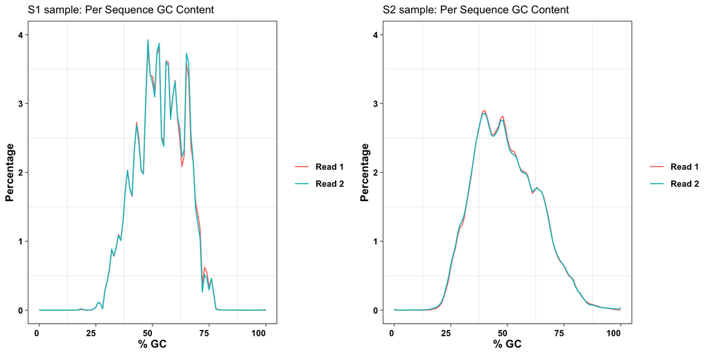

Generally speaking, the sequence GC content distribution in the S2 sample is closer to a normal distribution, while the S1 sample displays sharp peaks which are likely a result of the specific enrichment of low-complexity sequences with distinct GC sequence content (see also sequence duplication levels).

### Insert Size Estimation

This estimation is based on paired-end overlap analysis and displays the insert size distribution of the library fragments subjected to PE150 sequencing.

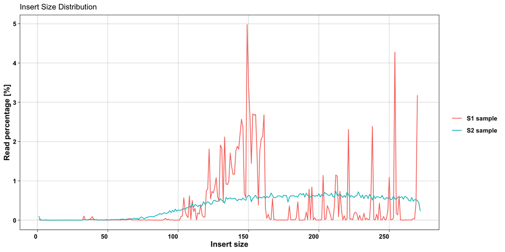

### Illumina Universal Adapter Content

To follow up on the suspicion of adapter contamination, I next investigated the cumulative percentage count of the proportion of the library which has seen each of the adapter sequences at each position.

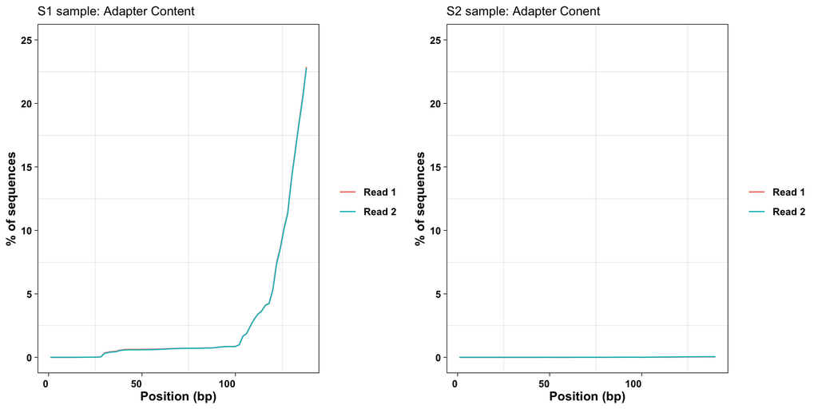

Indeed, I find a strong increase of Illumina Universal adapter content in both, forward and reverse read, from read position ~100 onwards, which is a likely consequence of the small insert size of the S1 sample found earlier. The S2 sample does not show any signs of adapter content throughout the reads.

# Genome coverage assessment

To assess the genome coverage of both approaches, I first had a look at the target BED files, the regions they cover and how the on-target performance of the target capturing assay behaves. Briefly, samples were aligned with [BWA](https://github.com/lh3/bwa), duplicates marked with [GATK4](https://github.com/broadinstitute/gatk) and genome coverage and on-target performance assessed using [bedtools](https://bedtools.readthedocs.io/en/latest/), [samtools](http://www.htslib.org/) and mosdepth.

[output not shown]

There are two noteworthy observations here: a) the target region size in both approaches is the roughly the same and b) the S1 approach presents with very good on-target enrichment (95%), whereas the S2 approach contains ~50% on-target reads.

### Cumulative Coverage Distribution

Mosdepth allows depth calculation of aligned BAM files. Utilizing the aligned BAM files together with the provided target region BED files, we can look at three crucial discriminant of the two target sequencing approaches.

First, I analysed the cumulative coverage distribution, which depicts the proportion of bases in the reference genome (hg19) while sub-setting the region of analysis to the provided target regions of S1 (AH_S1_target.txt) and S2 (CH_S2_target.txt).

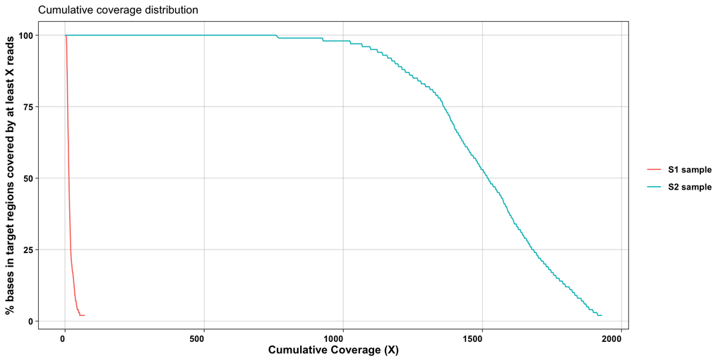

This data hhighlights the stark contrast in target region coverage by both approaches. In the S1 approach only 4x coverage is achieved for 100% of the bases in the target region, whereas for the S2 approach, 758x coverage is achieved for 100% of the bases in the target region.

### Average Coverage per contig

We can also compare the average coverage per target regions on a per chromosome level:

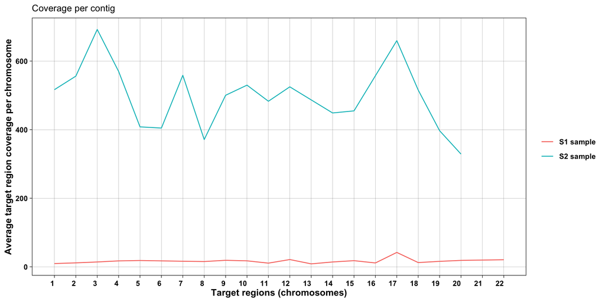

Please note that throughout all target regions the S2 approach presents with higher average coverage compared to the S1 approach. Nota bene: The S1 approach also targets regions in chr21 and chr22, whereas the S2 approach target set is limited to chr1-chr20.

# Variant calling

Finally, I performed some basic variant calling using freebayes. While the variants called in both approaches are not 1-to-1 comparable due to the different target regions, the variant depth in each datasets highlights once more the superiority of the S2 approach.

First, some general variant calling stats from both approaches:

| Sample | Variants | SNP | Indel | Ts/Tv |  |
| --- | --- | --- | --- | --- | --- |
| S1 | 64 | 59 | 3 | 2.28 |  |
| S2 | 31 | 26 | 5 | 1.89 |  |

Freebayes calls overall more variants in the S1 sample, but the variant depth is - as expected - extremely low and the S2 approach presents with a minimum variant depth of 500x for 100% of called variants:

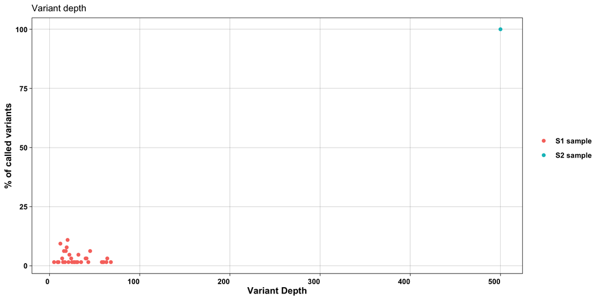

# Final performance evaluation

Based on the presented data I come to the following conclusion: I would chose the S2 approach for my lab to facilitate clinical diagnose.

The main reasons are the following:

- high-complexity enrichment of target regions
- no adapter contamination and uniform insert size distribution in the target library
- high and uniform genome coverage in the target region

# Software Versions

### External software tools

| Software | Version |
| --- | --- |
| bwa | 0.7.17-r1188 |
| samtools | 1.16.1 |
| gawk | 5.1.0 |
| python | 3.10.6 |
| yaml | 6.0 |
| fastp | 0.23.2 |
| fastqc | 0.11.9 |
| gatk4 | 4.3.0.0 |
| samtools | 1.16.1 |
| mosdepth | 0.3.3 |
| samtools | 1.16.1 |
| samtools | 1.16.1 |
| tabix | 1.12 |
| freebayes | 1.3.6 |
| vcftools | 0.1.16 |
| bcftools | 1.16 |